# Homework5

## STA 141A: Assignment 5

### Jiawei Zhu 923312684

## Question 1

Generate a synthetic dataset with 300 observations and 6 features, $X = (X_1, X_2, X_3, X_4, X_5, X_6)^{\mathrm{T}}$, where $X_1, X_2$ are positively correlated, $X_3, X_4$ are positively correlated, and $X_5, X_6$ are white noise that are independent with others.

1. Simulate $300$ observations from a $6$-dimensional multivariate normal distribution with a covariance matrix of your choice that satisfies the above structure.
2. Standardize all 6 variables separately.
3. Perform PCA on the standardized dataset using `prcomp()`.
4. Create a scree plot (variances or proportion of variance explained).
5. Using the loadings, interpret what PC1 and PC2 represent in terms of the original variables.

```r
#Set up
set.seed(141)

library(cluster)   # for silhouette and clustering tools

library(tidyverse)
```

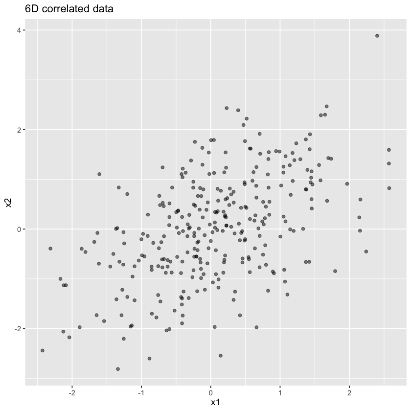

```r
# 1 (1)
library(MASS)

Sigma6 <- matrix(c(
  1, 0.5, 0,   0,   0, 0,
  0.5, 1, 0,   0,   0, 0,
  0,   0, 1, 0.5,   0, 0,
  0,   0, 0.5, 1,   0, 0,
  0,   0, 0,   0,   1, 0,
  0,   0, 0,   0,   0, 1
), nrow = 6)

df6 <- as_tibble(mvrnorm(300, mu = c(0, 0, 0, 0, 0, 0), Sigma = Sigma6))
colnames(df6) <- c("x1", "x2", "x3", "x4", "x5", "x6")

ggplot(df6, aes(x = x1, y = x2)) +
  geom_point(alpha = 0.5) +
  labs(title = "6D correlated data",
       x = "x1", y = "x2")
```

```r
# 1 (2) (3)
pca6 <- prcomp(df6, center = TRUE, scale. = TRUE)
summary(pca6)
print(pca6$rotation)
```

```
Importance of components:
                          PC1    PC2    PC3    PC4     PC5    PC6
Standard deviation     1.3115 1.1535 1.0162 0.9911 0.70374 0.6627
Proportion of Variance 0.2867 0.2218 0.1721 0.1637 0.08254 0.0732
Cumulative Proportion  0.2867 0.5084 0.6805 0.8442 0.92680 1.0000
```

```
          PC1         PC2          PC3         PC4        PC5        PC6
x1 -0.4919750 -0.51385406 -0.151373478 -0.01104660 -0.1756002 -0.6633576
x2 -0.4904156 -0.49548723  0.203149619  0.12295249  0.1451353  0.6607069
x3 -0.4899700  0.50227918  0.041025775  0.02430417 -0.6951972  0.1485667
x4 -0.4669926  0.47279224  0.009745746  0.33001641  0.6406917 -0.1972148
x5 -0.1404024  0.08741610  0.653831578 -0.71016285  0.1460332 -0.1396170
x6  0.1989663 -0.08359399  0.711717976  0.60903847 -0.1816302 -0.2072790
```

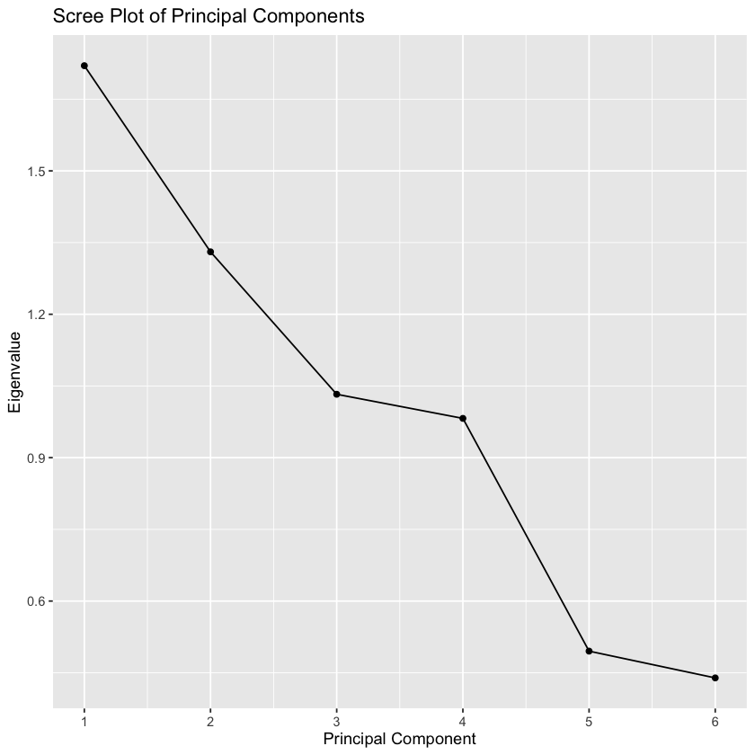

```r
# 1 (4)

pca_m_df <- tibble(
  PC = 1:6,
  eigenvalues = pca6$sdev^2,
  prop_var = eigenvalues / sum(eigenvalues),
  cum_var = cumsum(prop_var)
)
 ggplot(pca_m_df, aes(x = PC, y = eigenvalues)) +
  geom_line() +
  geom_point() +
  scale_x_continuous(breaks = 1:6) +
  labs(
    title = "Scree Plot of Principal Components",
    x = "Principal Component",
    y = "Eigenvalue"
  )
```

### Question 1 (5)

### PC1 has an index of the overall "signal" stength, it represents the average between x1, x2, x3 and x4. PC2 shows a difference between first pair (x1 and x2) to the second pair (x3 and x4). The x5 and x6 does not have no or littile influence between either.

## Question 2

We will revisit the built-in `USArrests` dataset.

1. Convert `USArrests` to a tibble with a `State` column.
2. Perform PCA on the unscaled variables (using `prcomp`, `scale. = FALSE`).
3. Perform PCA on the scaled variables (using `scale()` first or `scale. = TRUE`).
4. For each PCA, create a scree plot (variance or proportion of variance explained).
5. Compare the loadings for PC1 and PC2 from the two analyses. Which variables dominate PC1 and PC2 in each case?

```r
# 2 (1) (2)

library(tidyverse)


arrests <- USArrests %>%
  as_tibble(rownames = "State")

X_arrests <- arrests %>%
  dplyr::select(-State)

unscaled_pca_arrests <- prcomp(X_arrests, center = TRUE, scale. = FALSE)
summary(unscaled_pca_arrests)
unscaled_pca_arrests$rotation
```

```
Importance of components:
                           PC1      PC2    PC3     PC4
Standard deviation     83.7324 14.21240 6.4894 2.48279
Proportion of Variance  0.9655  0.02782 0.0058 0.00085
Cumulative Proportion   0.9655  0.99335 0.9991 1.00000
```

A matrix: 4 × 4 of type dbl

|  | PC1 | PC2 | PC3 | PC4 |
| --- | --- | --- | --- | --- |
| Murder | 0.04170432 | -0.04482166 | 0.07989066 | -0.99492173 |
| Assault | 0.99522128 | -0.05876003 | -0.06756974 | 0.03893830 |
| UrbanPop | 0.04633575 | 0.97685748 | -0.20054629 | -0.05816914 |
| Rape | 0.07515550 | 0.20071807 | 0.97408059 | 0.07232502 |

```r
# 2 (3)
X_arrests_scaled <- scale(X_arrests)
pca_arrests <- prcomp(X_arrests_scaled, center = TRUE, scale. = TRUE)
summary(pca_arrests)
pca_arrests$rotation
```

```
Importance of components:
                          PC1    PC2     PC3     PC4
Standard deviation     1.5749 0.9949 0.59713 0.41645
Proportion of Variance 0.6201 0.2474 0.08914 0.04336
Cumulative Proportion  0.6201 0.8675 0.95664 1.00000
```

A matrix: 4 × 4 of type dbl

|  | PC1 | PC2 | PC3 | PC4 |
| --- | --- | --- | --- | --- |
| Murder | -0.5358995 | -0.4181809 | 0.3412327 | 0.64922780 |
| Assault | -0.5831836 | -0.1879856 | 0.2681484 | -0.74340748 |
| UrbanPop | -0.2781909 | 0.8728062 | 0.3780158 | 0.13387773 |
| Rape | -0.5434321 | 0.1673186 | -0.8177779 | 0.08902432 |

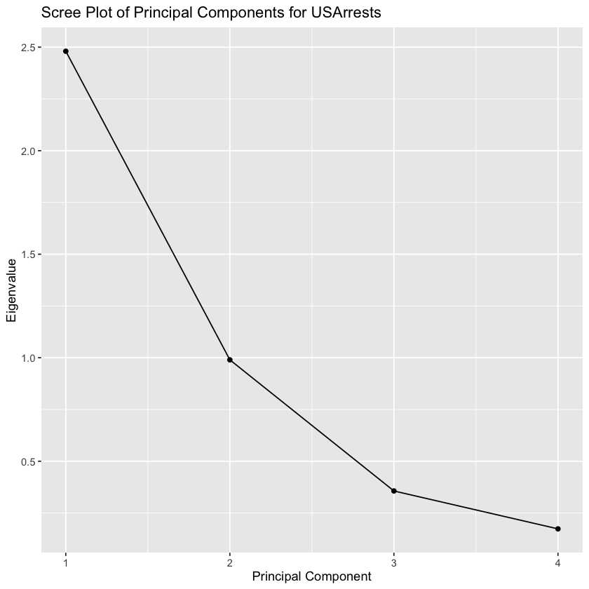

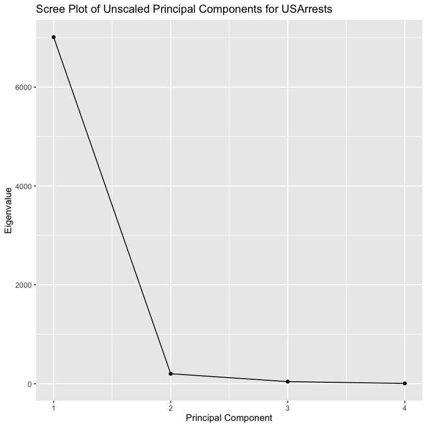

```r
# 2 (4)
pca_arrests_df <- tibble(
  PC = 1:4,
  eigenvalues = pca_arrests$sdev^2,
  prop_var = eigenvalues / sum(eigenvalues),
  cum_var = cumsum(prop_var)
)
ggplot(pca_arrests_df, aes(x = PC, y = eigenvalues)) +
  geom_line() +
  geom_point() +
  scale_x_continuous(breaks = 1:4) +
  labs(
    title = "Scree Plot of Principal Components for USArrests",
    x = "Principal Component",
    y = "Eigenvalue"
  )

  unscaled_pca_arrests_df <- tibble(
    PC = 1:4,
    eigenvalues = unscaled_pca_arrests$sdev^2,
    prop_var = eigenvalues / sum(eigenvalues),
    cum_var = cumsum(prop_var)
  )
  ggplot(unscaled_pca_arrests_df, aes(x = PC, y = eigenvalues)) +
    geom_line() +
    geom_point() +
    scale_x_continuous(breaks = 1:4) +
    labs(
      title = "Scree Plot of Unscaled Principal Components for USArrests",
      x = "Principal Component",
      y = "Eigenvalue"
    )
```

### In both analyze, the PC2 mostly depend on the UrbanPop,it shows the urbanization between different states.

## Question 3

Use the `iris` dataset in `R` and consider only the four numeric variables.

1. Scale the numeric variables and run PCA.
2. Plot the first two principal components (PC1 vs PC2), coloring points by `Species`.
3. Reconstruct the original (scaled) data using:
   - only the first principal component,
   - the first two principal components,
   - the first three principal components.
4. For each reconstruction, compute the mean squared error (MSE) between the scaled original data and the reconstructed data.
5. Comment on the tradeoff between dimension reduction and reconstruction error.

```r
# 3
iris_df <- iris |>
  as_tibble()

X_iris <- iris_df |>
  dplyr::select(-Species)
X_iris_scaled <- scale(X_iris)

pca_iris <- prcomp(X_iris_scaled, center = TRUE, scale. = FALSE)
summary(pca_iris)
```

```
Importance of components:
                          PC1    PC2     PC3     PC4
Standard deviation     1.7084 0.9560 0.38309 0.14393
Proportion of Variance 0.7296 0.2285 0.03669 0.00518
Cumulative Proportion  0.7296 0.9581 0.99482 1.00000
```

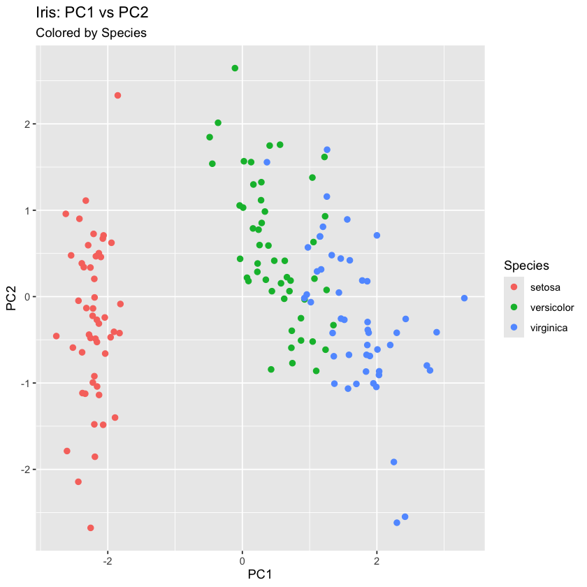

```r
# 3 (2)
pc_scores <- as_tibble(pca_iris$x) |>
  mutate(Species = iris_df$Species)

ggplot(pc_scores, aes(x = PC1, y = PC2, color = Species)) +
  geom_point(size = 2) +
  labs(title = "Iris: PC1 vs PC2",
       subtitle = "Colored by Species")
```

```r
# 3 (3)
recon_scaled <- pca_iris$rotation

recon_1 <- pca_iris$x[, 1, drop = FALSE] %*% t(pca_iris$rotation[, 1, drop = FALSE])
recon_2 <- pca_iris$x[, 1:2,drop = FALSE] %*% t(pca_iris$rotation[, 1:2])
recon_3 <- pca_iris$x[, 1:3,drop = FALSE] %*% t(pca_iris$rotation[, 1:3])

head(recon_1)
head(recon_2)
head(recon_3)
```

A matrix: 6 × 4 of type dbl

| Sepal.Length | Sepal.Width | Petal.Length | Petal.Width |
| --- | --- | --- | --- |
| -1.176119 | 0.6079552 | -1.310074 | -1.274961 |
| -1.080697 | 0.5586301 | -1.203784 | -1.171520 |
| -1.227806 | 0.6346728 | -1.367648 | -1.330991 |
| -1.194130 | 0.6172654 | -1.330137 | -1.294486 |
| -1.241107 | 0.6415486 | -1.382464 | -1.345411 |
| -1.077929 | 0.5571992 | -1.200701 | -1.168519 |

A matrix: 6 × 4 of type dbl

| Sepal.Length | Sepal.Width | Petal.Length | Petal.Width |
| --- | --- | --- | --- |
| -0.9955537 | 1.04968185 | -1.298357 | -1.242934 |
| -1.3342779 | -0.06171627 | -1.220240 | -1.216497 |
| -1.3564172 | 0.32004468 | -1.375994 | -1.353803 |
| -1.4188447 | 0.06753525 | -1.344719 | -1.334343 |
| -0.9977955 | 1.23677487 | -1.366675 | -1.302255 |
| -0.5177642 | 1.92755953 | -1.164350 | -1.069163 |

A matrix: 6 × 4 of type dbl

| Sepal.Length | Sepal.Width | Petal.Length | Petal.Width |
| --- | --- | --- | --- |
| -0.9039676 | 1.0185770 | -1.316447 | -1.323664 |
| -1.1660249 | -0.1188590 | -1.253473 | -1.364806 |
| -1.3881169 | 0.3308106 | -1.369732 | -1.325861 |
| -1.4843146 | 0.0897704 | -1.331788 | -1.276633 |
| -1.0090824 | 1.2406082 | -1.364446 | -1.292306 |
| -0.5371048 | 1.9341281 | -1.160530 | -1.052115 |

```r
# 3 （4）
recon_1_mse <- mean((X_iris_scaled - recon_1)^2)
recon_2_mse <- mean((X_iris_scaled - recon_2)^2)
recon_3_mse <- mean((X_iris_scaled - recon_3)^2)

cat("Reconstruction MSE for 1 component:", recon_1_mse, "\n")
cat("Reconstruction MSE for 2 components:", recon_2_mse, "\n")
cat("Reconstruction MSE for 3 components:", recon_3_mse, "\n")
```

[output not shown]

### 3 component: The error be the lowest (MSE = 0.005), but can earn almost nothing.

### The tradeoff heavy should be stops at 2 components, with 1 component has spike too much errors, with 3 componet can not earn too much benenfit

## Question 4

Use the scaled `USArrests` dataset.

1. Convert `USArrests` to a tibble with a `State` column and scale the numeric variables.
2. Compute a Euclidean distance matrix on the scaled variables.
3. Perform classical MDS using `cmdscale()` with `k = 2` dimensions.
4. Make a scatterplot of the two-dimensional MDS embedding and label or color points by region (`state.region`).
5. Interpret the MDS plot: do states with similar crime patterns tend to cluster together? Do regions tend to group?

```r
# 4
data("USArrests")

arrests <- USArrests |>
  as_tibble(rownames = "State")

X_arrests <- arrests |>
  dplyr::select(-State)

q4_X_arrests_scaled <- scale(X_arrests)
head(q4_X_arrests_scaled)
```

A matrix: 6 × 4 of type dbl

| Murder | Assault | UrbanPop | Rape |
| --- | --- | --- | --- |
| 1.24256408 | 0.7828393 | -0.5209066 | -0.003416473 |
| 0.50786248 | 1.1068225 | -1.2117642 | 2.484202941 |
| 0.07163341 | 1.4788032 | 0.9989801 | 1.042878388 |
| 0.23234938 | 0.2308680 | -1.0735927 | -0.184916602 |
| 0.27826823 | 1.2628144 | 1.7589234 | 2.067820292 |
| 0.02571456 | 0.3988593 | 0.8608085 | 1.864967207 |

A tibble: 6 × 4

| V1 <dbl> | V2 <dbl> | State <chr> | Region <fct> |
| --- | --- | --- | --- |
| -0.9756604 | 1.1220012 | Alabama | South |
| -1.9305379 | 1.0624269 | Alaska | West |
| -1.7454429 | -0.7384595 | Arizona | West |
| 0.1399989 | 1.1085423 | Arkansas | South |
| -2.4986128 | -1.5274267 | California | West |
| -1.4993407 | -0.9776297 | Colorado | West |

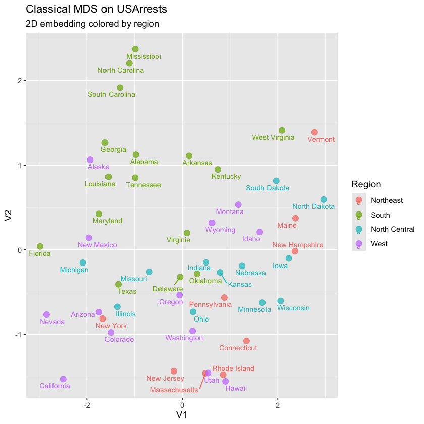

```r
#4 (2) (3) (4)

dist_arrests <- dist(q4_X_arrests_scaled, method = "euclidean")

mds6 <- cmdscale(dist_arrests, k = 2)

mds6_df <- as_tibble(mds6) %>%
  mutate(State = arrests$State,
         Region = state.region)

head(mds6_df)

ggplot(mds6_df, aes(x = V1, y = V2, color = Region, label = State)) +
  geom_point(size = 3, alpha = 0.7) +
  geom_text_repel(vjust = 0.2, size = 3) +
  labs(title = "Classical MDS on USArrests",
       subtitle = "2D embedding colored by region")
```

## Question 5

1. Create a dataset with 4 clusters, each with 50 observations. Let the 10-dimensional mean vectors for the clusters be well-separated (e.g., along different coordinates), and use a common covariance matrix (e.g., identity).
2. Combine the clusters into a single data frame and scale all variables.
3. Perform PCA and create a scatterplot of the first two principal components, colored by the true cluster labels.
4. Compute a Euclidean distance matrix on the scaled data and perform classical MDS with `k = 2`. Plot the 2D MDS embedding, again colored by the true cluster labels.
5. Repeat the procedure on unscaled data. Summarize your findings. (You may also play with the dimension.)

```r
# 5 (1) (2)
q5_clusters <- 4
q5_observations <- 50
q5_dimensions <- 10

sigma <- diag(q5_dimensions)
new_1 <- mvrnorm(q5_observations, mu = rep(0, q5_dimensions), Sigma = sigma)
new_2 <- mvrnorm(q5_observations, mu = rep(3, q5_dimensions), Sigma = sigma)
new_3 <- mvrnorm(q5_observations, mu = c(rep(0, q5_dimensions/2), rep(3, q5_dimensions/2)), Sigma = sigma)
new_4 <- mvrnorm(q5_observations, mu = c(rep(3, q5_dimensions/2), rep(0, q5_dimensions/2)), Sigma = sigma)

q5_data <- rbind(new_1, new_2, new_3, new_4)
q5_data_df <- as_tibble(q5_data) %>%
  mutate(Cluster = factor(rep(1:q5_clusters, each = q5_observations)))
q5_data_scaled <- q5_data_df %>%
  dplyr::select(-Cluster) %>%
  scale()
head(q5_data_scaled)
```

A matrix: 6 × 10 of type dbl

| V1 | V2 | V3 | V4 | V5 | V6 | V7 | V8 | V9 | V10 |
| --- | --- | --- | --- | --- | --- | --- | --- | --- | --- |
| -1.10414779 | -1.3411905 | -0.2938826 | -0.9674926 | -0.5277591 | -0.2486113 | -0.6208907 | -1.1191332 | -0.60989952 | -0.9650148 |
| -0.47260471 | -0.8644408 | -0.3464389 | 0.2153220 | -0.8334300 | -0.5731353 | -1.1070413 | -1.2893443 | -1.28601808 | -0.8836490 |
| -0.77431955 | -0.6611421 | -0.5052242 | -1.6031352 | -0.3304585 | -0.4295052 | -1.3858896 | -0.8424332 | -0.59219602 | -0.9896910 |
| -1.29301100 | -0.7598867 | -2.0601449 | -1.2651736 | -0.7494327 | -1.4046718 | -1.3965276 | -1.0524848 | 0.35362182 | -1.4117632 |
| -0.01043247 | -0.6401822 | -0.9850283 | -1.0413332 | -0.5646680 | -0.6594183 | -1.1624000 | -0.5363942 | -0.91549142 | -0.4830566 |
| 0.45810050 | -1.1787719 | -0.9580425 | -1.2792486 | -1.1873838 | -0.2103696 | -0.7906676 | -0.5046284 | 0.03851807 | -0.0383078 |

```
Importance of components:
                          PC1    PC2     PC3     PC4     PC5     PC6     PC7
Standard deviation     1.9515 1.9093 0.64829 0.62070 0.59436 0.56703 0.53875
Proportion of Variance 0.3809 0.3645 0.04203 0.03853 0.03533 0.03215 0.02903
Cumulative Proportion  0.3809 0.7454 0.78743 0.82596 0.86128 0.89344 0.92246
                           PC8     PC9    PC10
Standard deviation     0.52109 0.50819 0.49556
Proportion of Variance 0.02715 0.02583 0.02456
Cumulative Proportion  0.94962 0.97544 1.00000
```

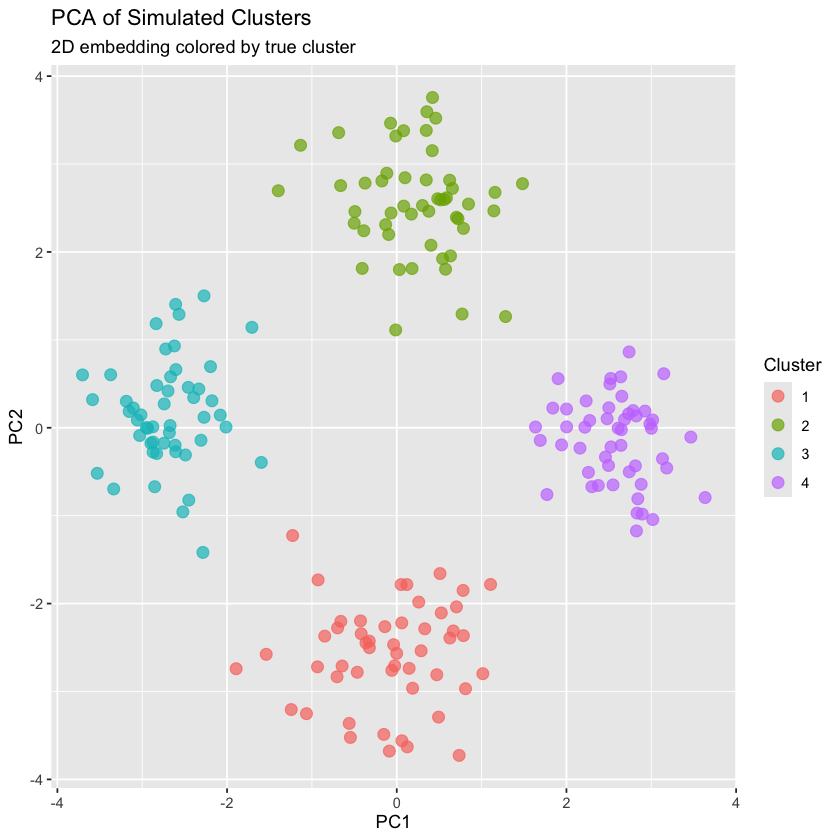

```r
# 5 (3)
q5_pca <- prcomp(q5_data_scaled, center = TRUE, scale. = FALSE)
summary(q5_pca)
q5_pca_df <- as_tibble(q5_pca$x) %>%
  mutate(Cluster = q5_data_df$Cluster)

ggplot(q5_pca_df, aes(x = PC1, y = PC2, color = Cluster)) +
  geom_point(size = 3, alpha = 0.7) +
  labs(title = "PCA of Simulated Clusters",
       subtitle = "2D embedding colored by true cluster")
```

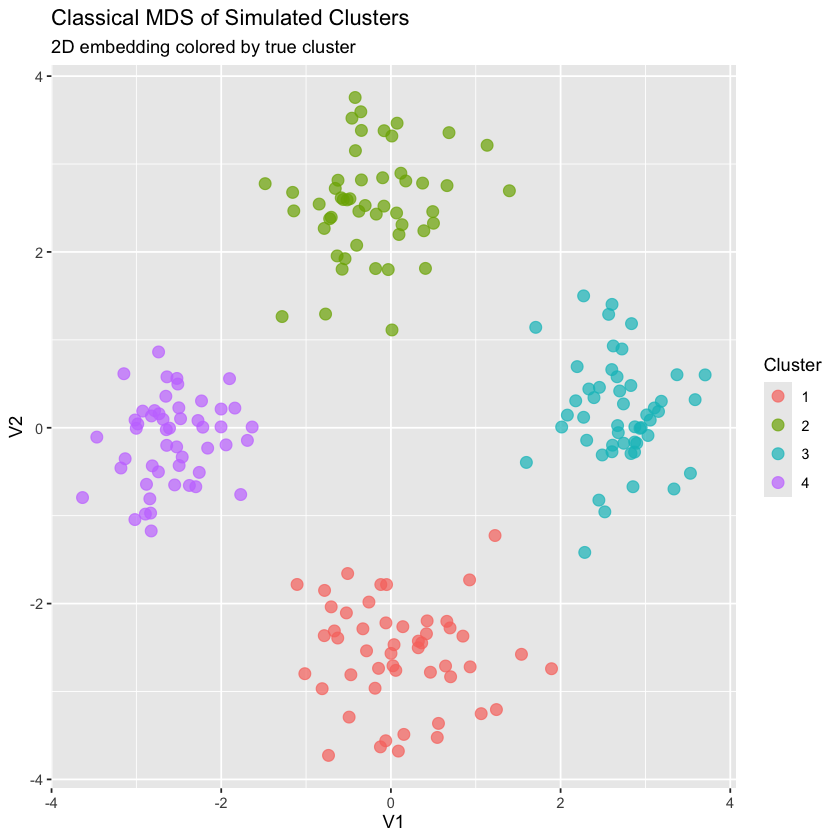

```r
# 5 (4)

q5_mds <- cmdscale(dist(q5_data_scaled), k = 2)
q5_mds_df <- as_tibble(q5_mds) %>%
  mutate(Cluster = q5_data_df$Cluster)

ggplot(q5_mds_df, aes(x = V1, y = V2, color = Cluster)) +
  geom_point(size = 3, alpha = 0.7) +
  labs(title = "Classical MDS of Simulated Clusters",
       subtitle = "2D embedding colored by true cluster")
```

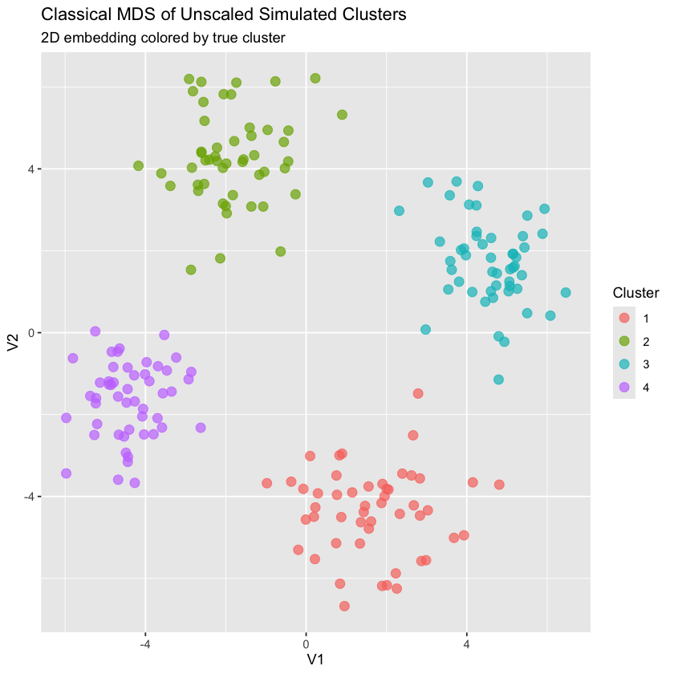

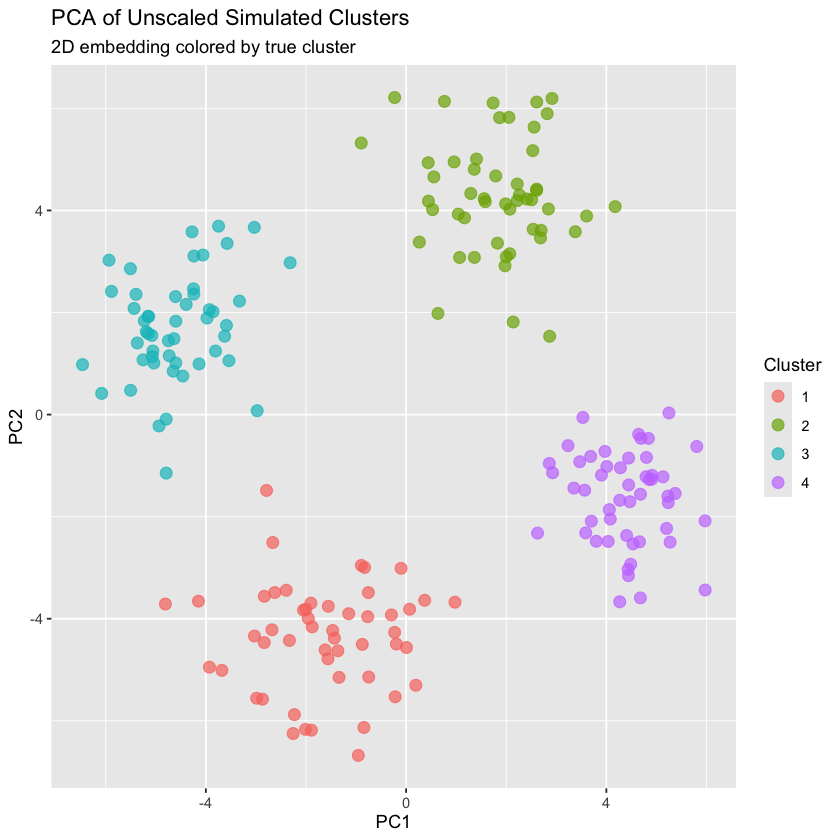

```r
# 5 （5）
unsclaed_q5 <- q5_data_df %>%
  dplyr::select(-Cluster)
q5_mds_unscaled <- cmdscale(dist(unsclaed_q5), k = 2)
q5_mds_unscaled_df <- as_tibble(q5_mds_unscaled) %>%
  mutate(Cluster = q5_data_df$Cluster)

ggplot(q5_mds_unscaled_df, aes(x = V1, y = V2, color = Cluster)) +
  geom_point(size = 3, alpha = 0.7) +
  labs(title = "Classical MDS of Unscaled Simulated Clusters",
       subtitle = "2D embedding colored by true cluster")

pca_unscaled_q5 <- prcomp(unsclaed_q5, center = TRUE, scale. = FALSE)
pca_unscaled_q5_df <- as_tibble(pca_unscaled_q5$x)
pca_unscaled_q5_df <- pca_unscaled_q5_df %>%
  mutate(Cluster = q5_data_df$Cluster)

ggplot(pca_unscaled_q5_df, aes(x = PC1, y = PC2, color = Cluster)) +
  geom_point(size = 3, alpha = 0.7) +
  labs(title = "PCA of Unscaled Simulated Clusters",
       subtitle = "2D embedding colored by true cluster")
```